# Radiomic features analysis of lung images in longitudinal studies

Andrea

11/23/2021

# Index

1. Introduction
2. Image display (oro.dicom)
3. Radiomic features (RIA)
4. Segmentation

   4.1. Segmentation with lungct

   4.2. Segmentation with Python (I)

   4.3. Segmentation with Python (II)

   4.4. Segmentation with lungmask
5. Radiomic features with masks

## 1. Introduction to radiomics

Medical images are essential for studying diseases. For example, to examine how a patient’s tumor evolves, we perform multiple scans over time. Interpreting how the tumor has changed by looking at the images is not an easy task, and different doctors may predict different outcomes. This is where computers become very useful. Thanks to artificial intelligence techniques, we can show computers different medical images over time of a patient with a tumor, and they can identify features of these images to make predictions. They can help decide whether a treatment for a tumor is working or not, decide which alternative treatment to use, and much more, without having to wait for the tumor to get worse.

In the last decades, several areas of human activities have experienced an increase in digitization. In the case of medicine, a significant amount of information generated during clinical routine has been digitized. With this digital increase, new and better software has been developed to analyze the data. Thanks to research in Artificial Intelligence, these methods have become very powerful and available to any user, allowing doctors to use them on a daily basis.

As the amount of data increases, different Artificial Intelligence techniques - mainly Machine Learning and Deep Learning - are of high utility to deal with this large amount of data, an area known as “Big Data”. In simple terms, Big Data refers to sets of data whose size, complexity and speed of growth make it difficult to analyze using traditional tools.

Radiomics is a field of medical study whose purpose consists of extracting a large volume of features from medical images using data characterization algorithms. These features are known as radiomic features and can help to discover tumor patterns that are difficult for the human eye to analyze. Radiomics is a relatively new scientific filed. The first radiomics studies appeared in PubMed as recently as 2011.

It is believed that, in the end, radiomics will use specific treatments for each patient, will help doctors select the most appropriate treatment for each patient, and will be able to change treatments quickly if they do not work.

Some of the difficulties when performing radiomics research is that high quality images, with adequate size and complete datasets are needed. Different training and validation datasets are also necessary, to check if our algorithm works correctly. Another difficulty is class imbalance (classification problem where the number of observations per class is not equally distributed) and overfitting (when a statistical model exactly fits its training data). The main clinical applications of radiomics are radiogenomics and clinical outcome prediction.

##### **Process of radiomics**

Now we will briefly explain the process of radiomics.

1. Obtain image: first, we obtain a medical image from a scanner (it can be obtained from multiple modalities: magnetic resonance imaging (MRI), computed tomography (CT), positron-emission-tomography (PET)…).
2. Image segmentation: this means dividing the image into multiple segments, in other words, delineating the areas of interest in the image in terms of pixels or voxels. This step can be done manually, semi-automatically or fully automatically.
3. Feature extraction: after image segmentation, we can extract the features and classify them.
4. Finally, we use databases to share our data.

##### **DICOM images**

In this project, we will study images obtained from scans of the lungs. The images we will obtain from the scans are DICOM images. DICOM (Digital Imaging and Communications in Medicine) is the standard for the communication and management of medical imaging information and related data. It is used worldwide to store, exchange, and transmit medical images. It defines the formats for medical images that can be exchanged with the data and quality necessary for clinical use. DICOM incorporates standards for imaging modalities such as radiography, ultrasonography, computed tomography (CT), magnetic resonance imaging (MRI), and radiation therapy. The most common applications of this standard are the display, storage, printing, and transmission of images.

##### **Radiomic techniques**

To obtain the features, we can use multiple techniques. Radiomic techniques can be divided into four categories: intensity-based metrics, texture-based analysis, shape-based measures, and transform-based metrics. We will briefly discuss these techniques now.

- Intensity-based metrics refers to statistics that are calculated from pixel values (or volumetric pixels called voxels). Additional information that can be obtained from analyzing the relationship between the voxels it is not considered. To compute the statistics, we select a region and extract the voxel values. They can be analyzed with histogram analysis. To quantify different aspects of the distribution we use average and variation, shape, and diversity.
- Texture-based analysis refers to the analysis of image patterns, such as intensity, shape, or colors. Mathematical formulas based on the spatial relationship of voxels are used to quantify these concepts.
- Shape-based measures refer to the study of different components of a structure. They can be divided into 1D metrics (measurement of the distance between two points. They are used to describe the magnitude of an abnormality), 2D metrics (calculated on cross-sectional planes and are used to calculate different parameters that are based on areas) and 3D metrics (attempt to enumerate different aspects of volumetric shape).
- Transform-based metrics refers to the transformation of images from spatial coordinates to what is called a frequency domain, without losing any information.

##### **Radiomic features**

We can obtain multiple types of features from images. Qualitative features are used to describe lesions, and quantitative features are extracted from images using computer programs that apply mathematical algorithms. Now, we will focus on quantitative features, which can be divided into different subgroups.

- Shape features describe the shape of the traced region of interest and its geometric properties like volume, maximum diameter along different orthogonal directions, maximum surface, tumor compactness, etc.
- First-order statistics features describe the distribution of individual voxel values without taking into account spatial relationships. Some properties we obtain are the mean, median, maximum, minimum values of the voxel intensities on the image, skewness, kurtosis, etc.
- Second-order statistics features include the textural features. They are obtained computing the statistical relationships between neighboring voxels.
- Higher-order statistics features are obtained by statistical methods after applying filters or mathematical transforms to the images. Some examples are fractal analysis, Minkowski functionals or Laplacian transforms of Gaussian-filtered images.

## 2. Image display (oro.dicom)

In this section we will display a few images using R.

The R package *oro.dicom* is a collection of input/output functions for medical imaging data that conform to the Digital Imaging and Communications in Medicine (DICOM) standard. The R package *RIA* is another package that was developed to facilitate radiomic analysis of medical images.

First we load the libraries oro.dicom and RIA.

```r
library(oro.dicom)
library(RIA)
```

Now we will display 3 images from the same patient (ID00007637202177411956430). To read the images we use the function *readDICOMFile(path_of_the_image)*.

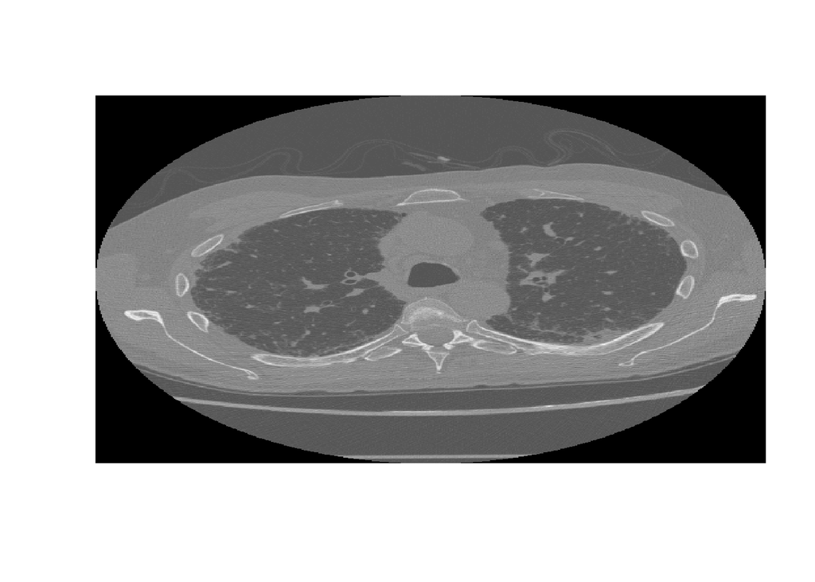

```r
image1 <- readDICOMFile("/Users/andrealetaalfonso/Desktop/TFG/images/Kaggle/ID00007637202177411956430/11/11.dcm")
image(t(image1$img), col=grey(0:64/64), axes=FALSE, xlab="", ylab="")
```

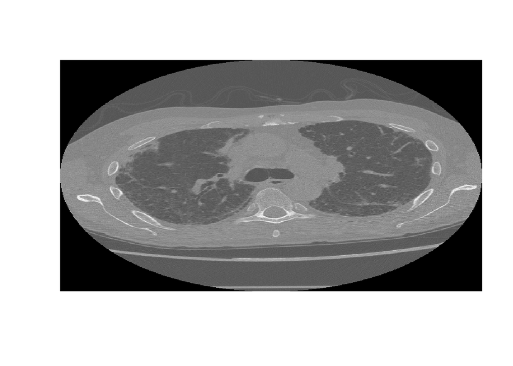

```r
image2 <- readDICOMFile("/Users/andrealetaalfonso/Desktop/TFG/images/Kaggle/ID00007637202177411956430/12/12.dcm")
image(t(image2$img), col=grey(0:64/64), axes=FALSE, xlab="", ylab="")
```

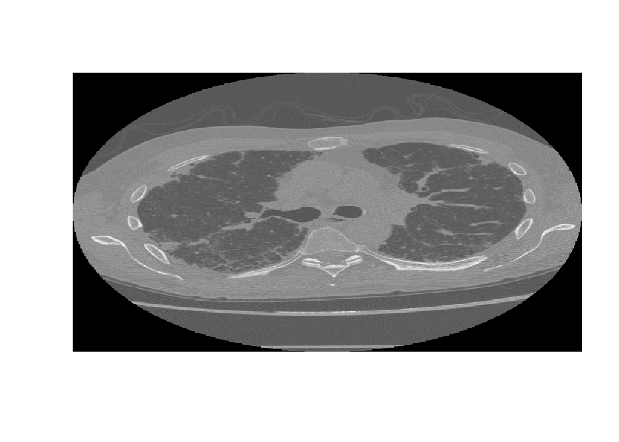

```r
image3 <- readDICOMFile("/Users/andrealetaalfonso/Desktop/TFG/images/Kaggle/ID00007637202177411956430/13/13.dcm")
image(t(image3$img), col=grey(0:64/64), axes=FALSE, xlab="", ylab="")
```

## 3. Radiomic features (RIA)

### Radiomic features without masks (RIA)

First we will compute the radiomic features of the images without masks.

To compute the radiomic features of the images using the library RIA, we first need to convert the DICOM images to RIA_image class. To do so, we will use the *load_dicom(path_of_the_file)* function.

If we have other image formats, there exist functions such as *load_nifti()*, *load_nrrd()* and *load_npy()* in RIA to read the images.

##### **1 image**

First, we compute the radiomic features of 1 image without a mask (we will do it for the first image displayed earlier). To compute the first-order statistics we use the *first_order()* function.

Some of the metrics computed are the mean, median, energy, entropy, and so on.

```r
DICOM <- RIA::load_dicom(filename="/Users/andrealetaalfonso/Desktop/TFG/images/Kaggle/ID00007637202177411956430/11", skipFirst128=FALSE, DICM=FALSE, boffset = 128)
DICOM = first_order(RIA_data_in = DICOM) # first order statistics
first_order <- RIA:::list_to_df(DICOM$stat_fo$orig) # list of first order statistics
name_characteristics <- rownames(first_order) # names of the first order statistics
```

```r
library(rmarkdown)
paged_table(first_order)
```

|  | Values |
| --- | --- |
| Mean | 1551.098172233 |
| Median | 1357.000000000 |
| Mode | 976.000000000 |
| Geo_mean | 37154.269847872 |
| Geo_mean2 | 37154.269847872 |
| Geo_mean3 | 1471.257423045 |
| Har_mean | 1398.432826766 |
| Trim_mean_5 | 1530.607674416 |
| Trim_mean_10 | 1521.999246242 |
| Trim_mean_20 | 1513.051787423 |

[output cut: 34 more lines]

##### **10 images**

Now we will compute the first order characteristics of 10 images (images 10 through 19) from the same patient (ID00007637202177411956430) without a mask.

```r
first_order <- c()
res <- c()
first_image <- 10 # first image to study
last_image <- 19 # last image to study
for (i in first_image:last_image) { # for loop through all the images
  path <- file.path("/Users", "andrealetaalfonso", "Desktop","TFG", "images", "Kaggle", "ID00007637202177411956430", i, fsep="/") # path of every image
  DICOM <- RIA::load_dicom(filename=path, skipFirst128=FALSE, DICM=FALSE, boffset = 128) # load dicom image
  DICOM = first_order(RIA_data_in = DICOM, use_type = "single") # compute first order characteristics
  first_order[i] <- RIA:::list_to_df(DICOM$stat_fo$orig)
  res[i-first_image+1] <- first_order[i] # data.frame counts from 1 to 10 (not first_image to last_image)
}
```

Finally, we combine all the results into a data.frame called ‘results’.

```r
library(rmarkdown)
results <- do.call(cbind.data.frame, res)
colnames(results) <- seq(1, last_image-first_image+1)
rownames(results) <- name_characteristics
#results:  results in a data.frame
paged_table(results, options = list(rows.print = 10, cols.print = 5))
```

|  | 1 | 2 | 3 | 4 | 5 | 6 | 7 | 8 | 9 | 10 |
| --- | --- | --- | --- | --- | --- | --- | --- | --- | --- | --- |
| Mean | 1540.683455120 | 1551.098172233 | 1555.910506270 | 1560.7833088 | 1579.756720873 | 1587.143328552 | 1597.964321710 | 1613.102712577 | 1640.2764328 | 1644.268636249 |
| Median | 1355.000000000 | 1357.000000000 | 1425.000000000 | 1435.0000000 | 1563.000000000 | 1654.000000000 | 1691.000000000 | 1751.000000000 | 1791.0000000 | 1791.000000000 |
| Mode | 976.000000000 | 976.000000000 | 976.000000000 | 976.0000000 | 976.000000000 | 976.000000000 | 976.000000000 | 976.000000000 | 976.0000000 | 976.000000000 |
| Geo_mean | 36852.514496287 | 37154.269847872 | 37469.728769588 | 37603.4965244 | 38327.754925132 | 38688.381239378 | 39046.708945007 | 39691.258567337 | 40668.1424909 | 40766.721966023 |
| Geo_mean2 | 36852.514496287 | 37154.269847872 | 37469.728769588 | 37603.4965244 | 38327.754925132 | 38688.381239378 | 39046.708945007 | 39691.258567337 | 40668.1424909 | 40766.721966023 |
| Geo_mean3 | 1462.964586056 | 1471.257423045 | 1479.904795909 | 1483.5648926 | 1503.312875246 | 1513.103130914 | 1522.803286975 | 1540.183205694 | 1566.3602301 | 1568.991030499 |
| Har_mean | 1391.407560321 | 1398.432826766 | 1409.172059604 | 1412.0342790 | 1431.333747544 | 1442.257550708 | 1451.045809234 | 1469.173129367 | 1493.2247829 | 1494.844260422 |
| Trim_mean_5 | 1522.775699552 | 1530.607674416 | 1539.183592276 | 1541.7875942 | 1562.289359054 | 1572.303064462 | 1581.076244300 | 1598.470656044 | 1626.5357351 | 1629.214451121 |
| Trim_mean_10 | 1516.315135461 | 1521.999246242 | 1533.293572598 | 1535.3340763 | 1556.565593100 | 1568.220921092 | 1576.214110350 | 1595.163533187 | 1624.1406459 | 1626.089492613 |
| Trim_mean_20 | 1508.791432967 | 1513.051787423 | 1527.110722117 | 1529.1036778 | 1552.120376988 | 1565.996547505 | 1573.942985378 | 1595.292317290 | 1626.1738664 | 1627.488207004 |

[output cut: 34 more lines]

## 4. Segmentation

As we explained in the introduction, segmentation refers to delineating the areas of interest in the image in terms of pixels or voxels, in our case, the lung. Lung segmentation refers to the computer-based process of identifying the boundaries of lungs from surrounding thoracic tissue on the scan images. Once we have the segmented images, we can start our analysis.

Now we will discuss different software to do lung segmentation.

### 4.1 Segmentation with lungct

We will use the library in R *lungct*. The lungct R package develops an image processing pipeline for computed tomography (CT) scans of the lungs.

First, we load the libraries needed to do the segmentation. We will use the library *dcm2niir* to convert DCM files to NIFTI.

```r
library(lungct)
library(dcm2niir)
library(ANTsRCore)
```

Now we have to convert the data from DCM to NII. NIFTI (Neuroimaging Informatics Technology Initiative) is a data format for the storage of Functional Magnetic Resonance Imaging (fMRI) and other medical images.

```r
res <- dcm2niir::dcm2nii(basedir="/Users/andrealetaalfonso/Desktop/TFG/images/Kaggle/ID00184637202242062969203")
checked <- check_dcm2nii(res) # Manipulating the output
```

Next we plot some images.

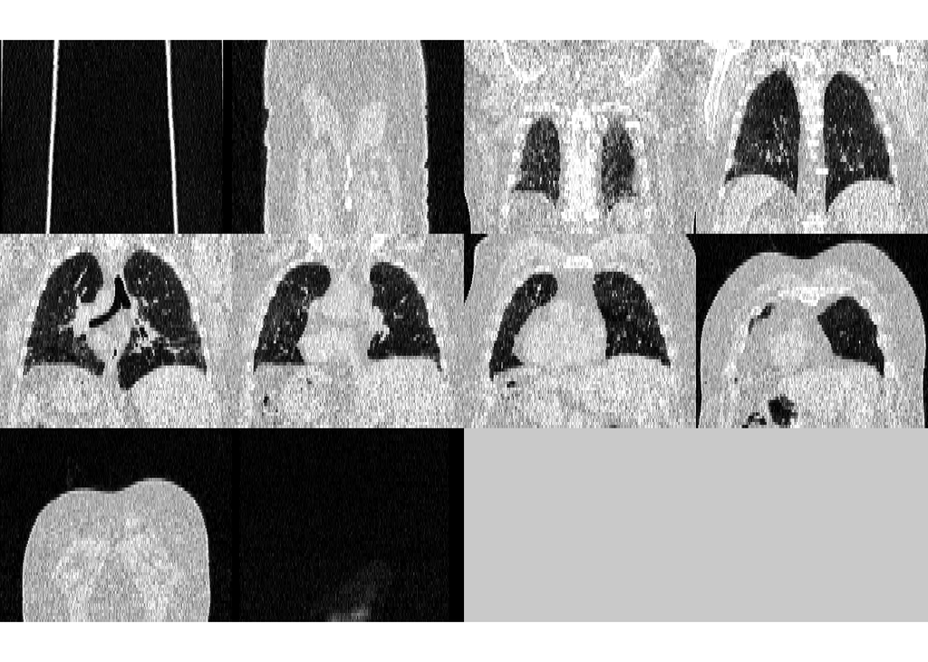

```r
image <- antsImageRead(checked)
plot(image)
```

We create the masks.

```r
mask <- segment_lung(image)
```

And finally, we plot some of the masks.

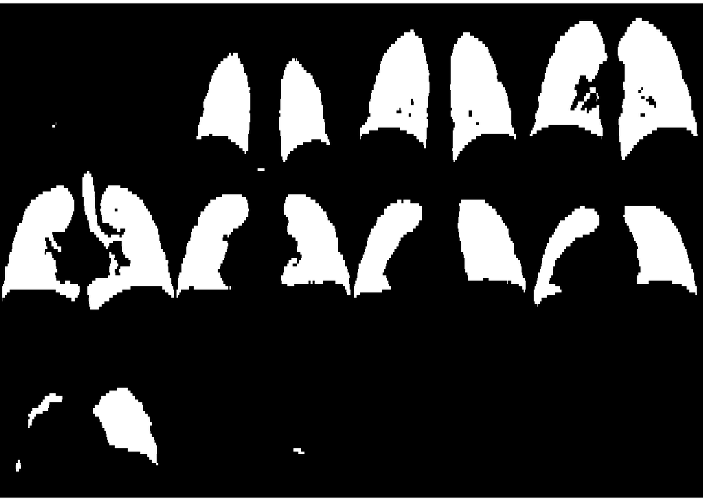

```r
plot(mask$lung_mask)
```

Now, we will do the same for another set of images.

```r
res2 <- dcm2niir::dcm2nii(basedir="/Users/andrealetaalfonso/Desktop/TFG/images/eclipse/id_1")
checked2 <- check_dcm2nii(res2) # Manipulating the output
```

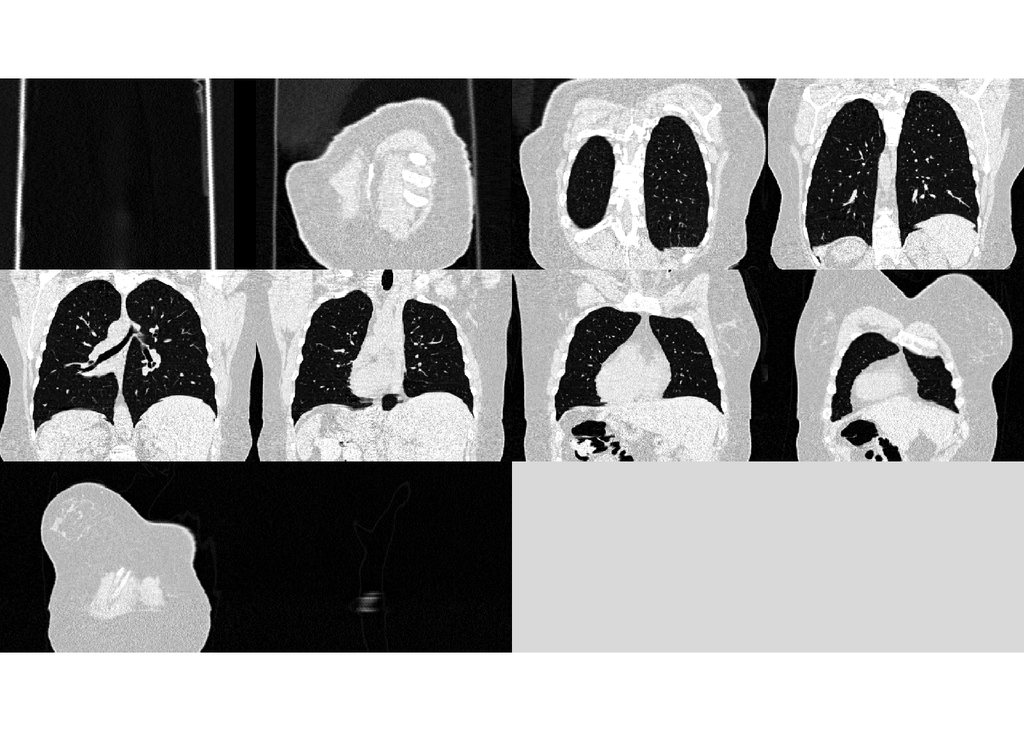

```r
image2 <- antsImageRead(checked2)
plot(image2)
```

```r
mask2 <- segment_lung(image2)
```

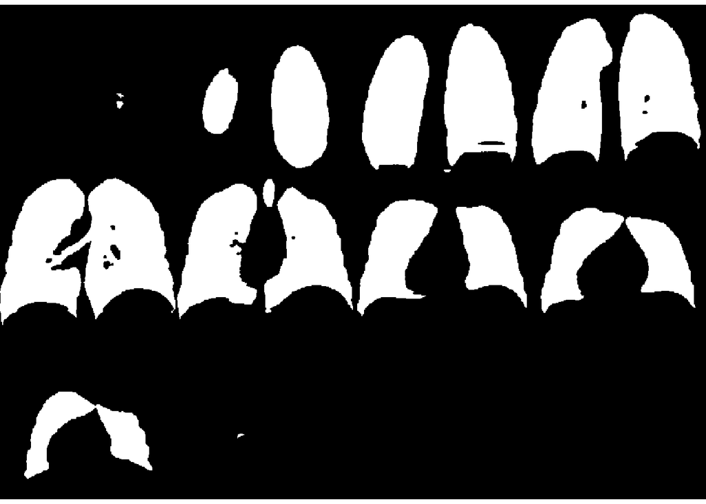

```r
plot(mask2$lung_mask)
```

#### **Radiomic features with masks (lungct)**

In this section we will compute the radiomic features of the images with masks, obtained with lungct.

```r
RIA_lung(
  image, mask$lung_mask,
  sides = c("right", "left"),
  features = c("fo"),
  bins_in = 16, equal_prob = FALSE, distance = 1,
  statistic = "mean(X, na.rm = TRUE)")
```

ERROR, IT DOES NOT WORK

##### **Radiomic features with masks with multiple patients (RIA, lungct)**

Now we will create multiple .txt files with the results of the radiomic features of different patients, using a mask.

The IDs of the patients are the following.

```r
patient1 <- "ID00007637202177411956430"
patient2 <- "ID00009637202177434476278"
patient3 <- "ID00010637202177584971671"
patient4 <- "ID00011637202177653955184"
patient5 <- "ID00012637202177665765362"
patient6 <- "ID00014637202177757139317"
patient7 <- "ID00015637202177877247924"
patient8 <- "ID00019637202178323708467"
patient9 <- "ID00020637202178344345685"
patient10 <- "ID00023637202179104603099"
vector_patients <- c(patient1, patient2, patient3, patient4, patient5, patient6, patient7, patient8, patient9, patient10) # list of patients ID
```

```r
for(patient in vector_patients){
  first_order <- c()
  path <- file.path("/Users", "andrealetaalfonso", "Desktop","TFG", "images", "Kaggle", patient, fsep="/") # path of every image
  number_files <- length(list.files(path)) # number of folders (ie. images) in each patient
  for (i in 1:number_files) { # for loop through all the images
    path <- file.path("/Users", "andrealetaalfonso", "Desktop","TFG", "images", "Kaggle", patient, i, fsep="/") # path of every image
    res <- dcm2niir::dcm2nii(basedir=path) # Convert the data from dcm to nii
    checked <- check_dcm2nii(res) # Manipulating the output
    image <- antsImageRead(checked)
    mask <- segment_lung(image) # Lung segmentation
    DICOM <- RIA::load_dicom(filename=path, mask_filename=path, skipFirst128=FALSE, DICM=FALSE, boffset = 128) # load dicom image + mask
    DICOM = first_order(RIA_data_in = DICOM, use_type = "single") # compute first order characteristics
    first_order[i] <- RIA:::list_to_df(DICOM$stat_fo$orig)
  }
  results <- do.call(cbind.data.frame, first_order)
  colnames(results) <- seq(1, number_files)
  rownames(results) <- name_characteristics
  write.table(results, row.names = TRUE, col.names=NA, file=paste0(patient,".txt"), sep="\t") # table with the results
}
```